# Train Longline BANTER Model

Selene Fregosi

27 May 2024

## Purpose

An initial Longline HARP BANTER model has been created as part of the Simonis et al. (in submission) manuscript, however, this model (`LLHARP_BANTER_2class_2023-05-31.rda`) does not include the same filtering as the towed array model and only includes data from longline trips through 2020. The purpose of this script is to generate an updated Longline BANTER model with some additional events from Phase 3 of the Longline Acoustic Montoring Project, some Phase 1 and 2 trips removed due to noise or other uncertainties, and with some processing adjustments to match that of the towed array model (include filtering of click detectors and remove calibration).

## Set up

### Load libraries

```r
library(banter)
library(rfPermute)
library(ggplot2)
library(beepr)
```

### Set paths and run type

```r
# path to save models
# path_models <- file.path('T:/glider_MHI_analysis', 'classification', 'models')
# path_models <- file.path('Z:/LLHARP/analysis/banterModels')
path_models <- file.path('T:/fregosi/cross_platform_banter_big_data/models')

# Re-generate/train model (1) or load existing model to view results (0)
freshRun <- 1
```

## Load training data

Training data was created with `ll1_combine_acoustic_studies.R`.

Alternatively, if this is not a fresh run to train a new model, load an existing model and just look at the results.

If loading `TrainingDataset_Pc_UO_Pm2023-05-30_edited.rda`, events are labeled Pc, UO and Pm. This `.rda` file is already exported for `banter`.

```r
# load(file = file.choose())
# load('Z:/LLHARP/processingCode/LLHARP/data/TrainingDataset_Pc_UO_Pm2023-05-30_edited.rda')
# load('Z:/LLHARP/processingCode/LLHARP/data/AllEventsTBP_Pc_UO_Pm2023-05-30_edited.rda')


if (freshRun == 1){
  # trainingFile <- file.path('Z:/LLHARP/analysis/banter2024/simonis_data',
  #                           'TrainingDataset_Pc_UO_Pm2023-05-30_edited.rda')
  trainingFile <- file.path('T:/fregosi/cross_platform_banter_big_data',
                            'banterDetsTrain_LLHARP_2024-05-27.rda')
  load(trainingFile)
  # load to-be-predicted file
  # TBPFile <-'Z:/LLHARP/analysis/banter2024/simonis_data/AllEvents_TBP_Pc_UO_Pm2023-05-30.rda'
  # load(TBPFile)
} else if (freshRun == 0){
  # modelFile <- file.path(path_models, 'LLHARP_BANTER_2class_2023-05-31.rda')
  modelFile <- file.path(path_models, 'bantMDL_LLHARP_2024-05-27.rda')
  load(modelFile)
  cat('Loaded existing model:', modelFile, '\n')
}
```

## Clean data

If the training data contains species other than just `Pc` or `UO`, they need to be cleaned up. Replace all non-Pc entries with `UO`.

Also, remove any ‘Click_Detector_0’ detections.

```r
if (freshRun == 1){
uSp <- unique(banterDetsTrain$events$species)
uSp <- uSp[-which(uSp == 'UO' | uSp == 'Pc')]

for (u in seq_along(uSp)){
  uSpIdx <- which(banterDetsTrain$events$species == uSp[u])
  banterDetsTrain$events$species[uSpIdx] <- 'UO'
}

# unique(banterDetsTrain$events$species)

# Check for click_detector_0 in training dataset
banterDetsTrain$detectors$Click_Detector_0 <- NULL
}
```

## Build the model

```r
if (freshRun == 1){
  # build the model
  bant.mdl <- initBanterModel(banterDetsTrain$events)
  bant.mdl <- addBanterDetector(
    bant.mdl,
    data =  banterDetsTrain$detectors,
    ntree = 40000,
    sampsize = 2
  )
  bant.mdl <- runBanterModel(bant.mdl, ntree = 10000, sampsize = 2)

  # save model
  save(bant.mdl, file = file.path(path_models, paste0('bantMDL_LLHARP_',
                                                      Sys.Date(), '.rda')))

  # get random forest data and save
  event.rf <- getBanterModel(bant.mdl, "event")
  save(event.rf, file = file.path(path_models, paste0('eventRF_LLHARP_',
                                                      Sys.Date(), '.rda')))
} else if (freshRun == 0){
  event.rf <- getBanterModel(bant.mdl, "event")
  cat('No model trained. Showing results from existing model:', modelFile, '\n')
}

# beepr::beep()
```

## View results

### Overall results (event model)

```r
summary(bant.mdl)
```

```
## Model run times:
##                           start                 stop
## Cepstrum_Detector         "2024-05-27 12:27:19" "2024-05-27 12:29:15"
## Click_Detector_1          "2024-05-27 12:47:08" "2024-05-27 12:54:36"
## Click_Detector_2          "2024-05-27 12:54:36" "2024-05-27 13:16:41"
## Click_Detector_3          "2024-05-27 13:16:41" "2024-05-27 13:39:52"
## Click_Detector_4          "2024-05-27 13:39:52" "2024-05-27 13:40:02"
## Click_Detector_5          "2024-05-27 13:40:02" "2024-05-27 13:40:20"
## Whistle_and_Moan_Detector "2024-05-27 12:29:15" "2024-05-27 12:47:08"
## event                     "2024-05-27 13:40:20" "2024-05-27 13:40:35"
##                           run.time
## Cepstrum_Detector         "1.94 mins"
## Click_Detector_1          "7.48 mins"
## Click_Detector_2          "22.08 mins"
## Click_Detector_3          "23.18 mins"
## Click_Detector_4          "9.48 secs"
## Click_Detector_5          "17.73 secs"
## Whistle_and_Moan_Detector "17.87 mins"
## event                     "14.7 secs"
##
## Number of events and model classification rate:
##   species num.events Cepstrum_Detector Click_Detector_1 Click_Detector_2
## 1      Pc         48             59.63            73.83            78.02
## 2      UO        395             72.20            64.96            73.40
## 3 Overall        443             67.51            67.65            74.12
##   Click_Detector_3 Click_Detector_4 Click_Detector_5 Whistle_and_Moan_Detector
## 1            64.94            72.41            72.22                     77.84
## 2            78.34            86.11            67.78                     77.37
## 3            78.16            85.70            68.18                     77.70
##   event
## 1 97.92
## 2 88.61
## 3 89.62
##
## Number of trees: 10000
##
## Sample sizes:
## Pc UO
##  2  2
##
## Distribution of percent correctly classified overall in last 5000 (50%) trees:
##    Min. 1st Qu.  Median    Mean 3rd Qu.    Max.
##   88.94   89.39   89.39   89.48   89.62   89.84
##
## Sample inbag proportion distribution:
##          Min. 1st Qu. Median Mean 3rd Qu. Max.
## expected  0.5     1.4    2.3  2.3     3.3  4.2
## observed  0.3     0.5    0.5  0.9     0.6  4.6
##
## Confusion matrix:
##         Pc  UO pct.correct LCI_0.95 UCI_0.95
## Pc      47   1    97.91667 88.93038 99.94727
## UO      45 350    88.60759 85.05417 91.56787
## Overall NA  NA    89.61625 86.39302 92.29701
```

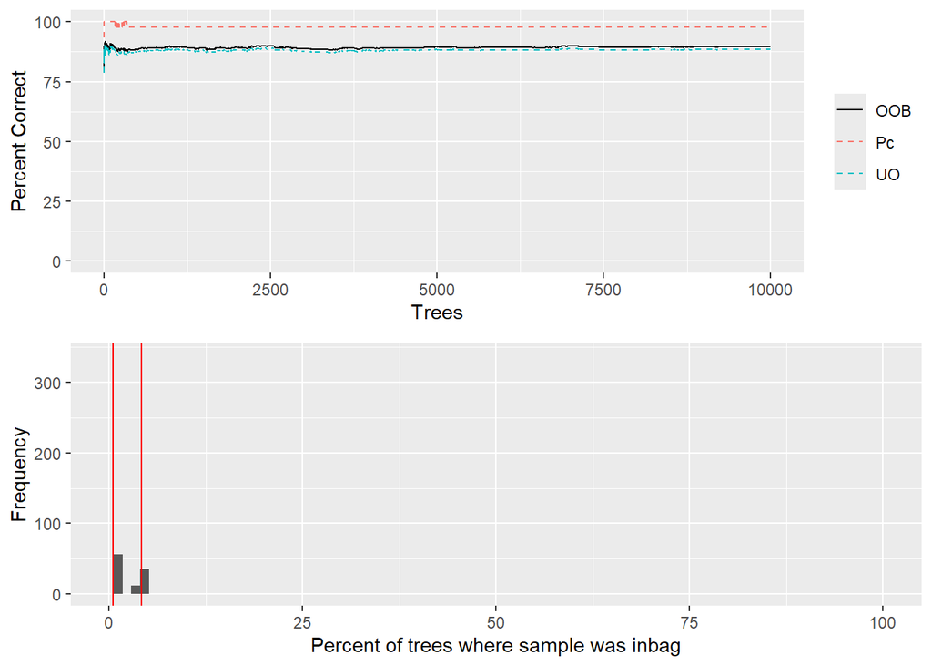

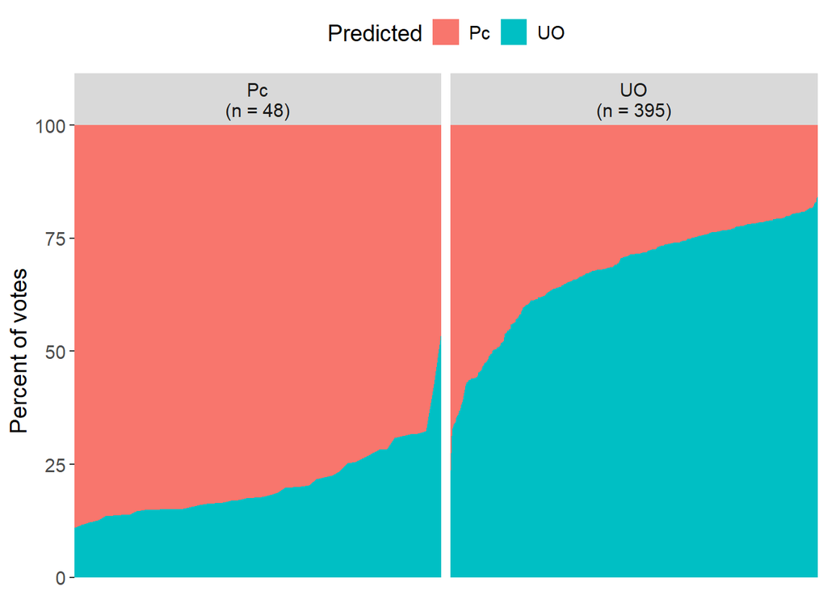

```r
plotVotes(event.rf)
```

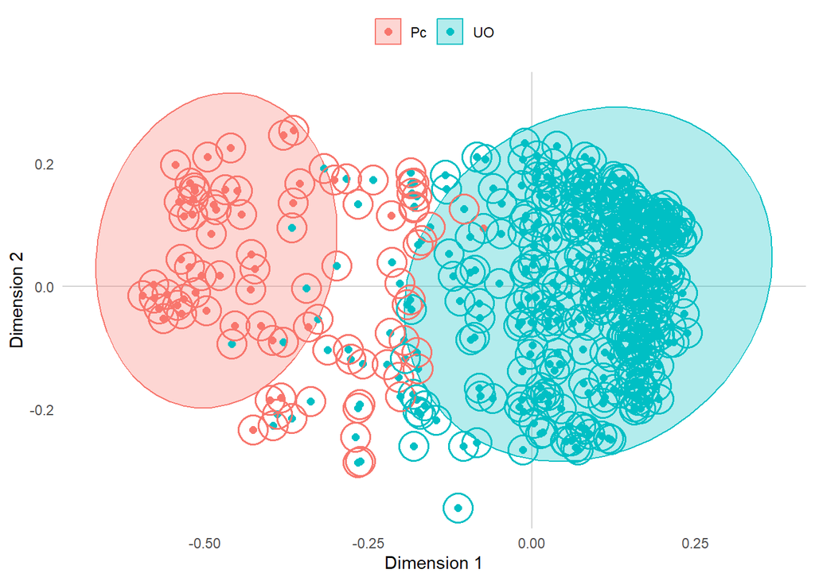

```r
plotProximity(event.rf)
```

### Detector results (detector models)

```
## Cepstrum_Detector
```

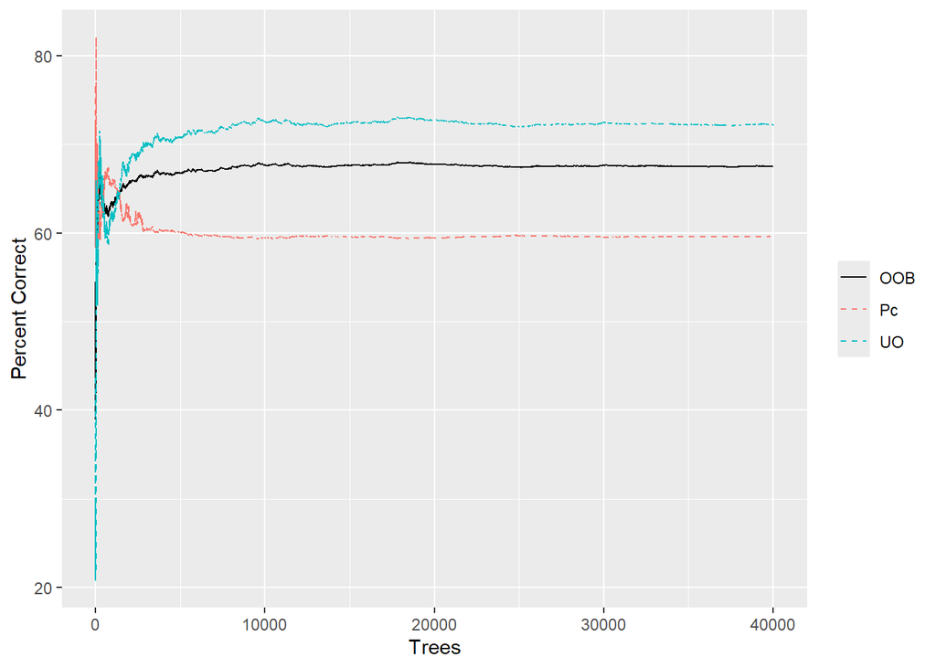

```
## Click_Detector_1
```

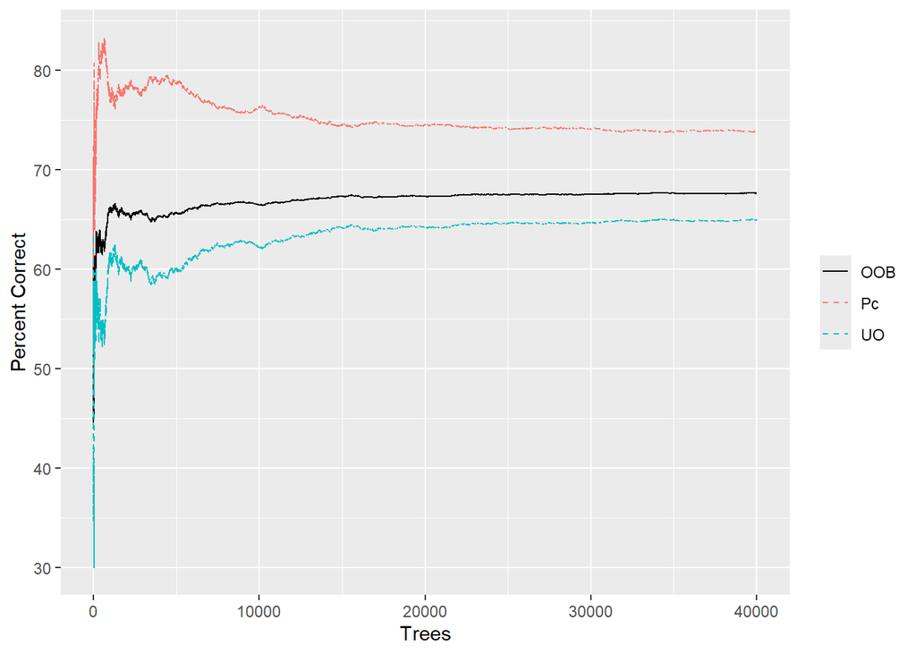

```
## Click_Detector_2
```

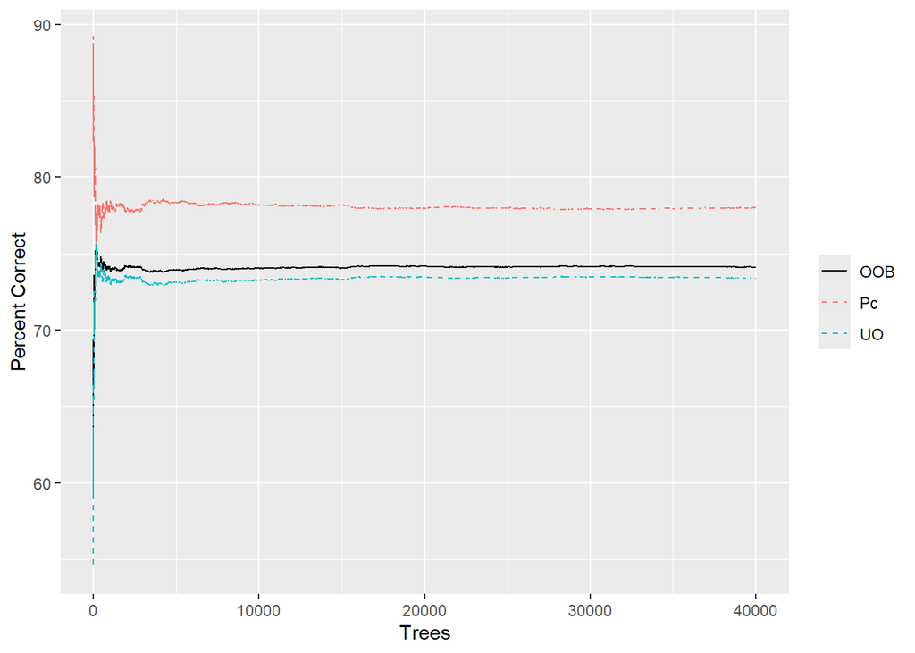

```
## Click_Detector_3
```

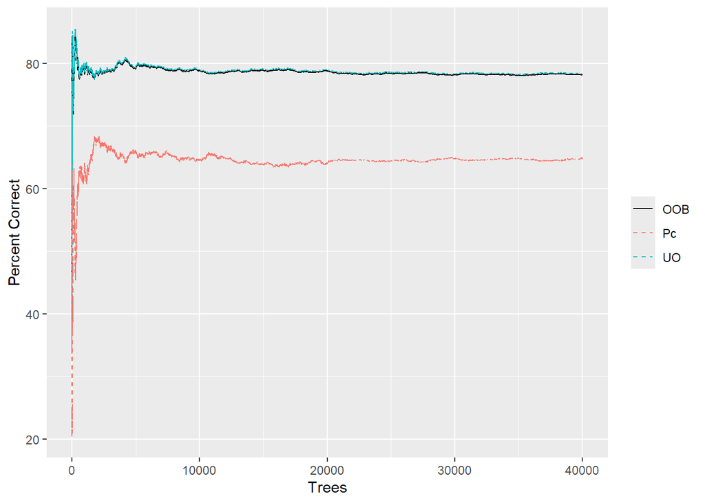

```
## Click_Detector_4
```

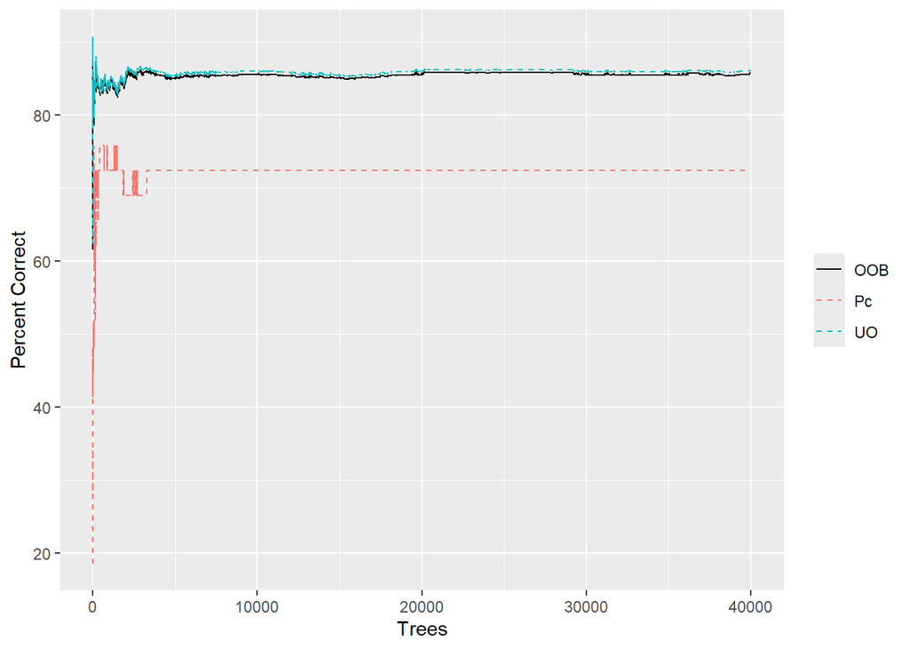

```
## Click_Detector_5
```

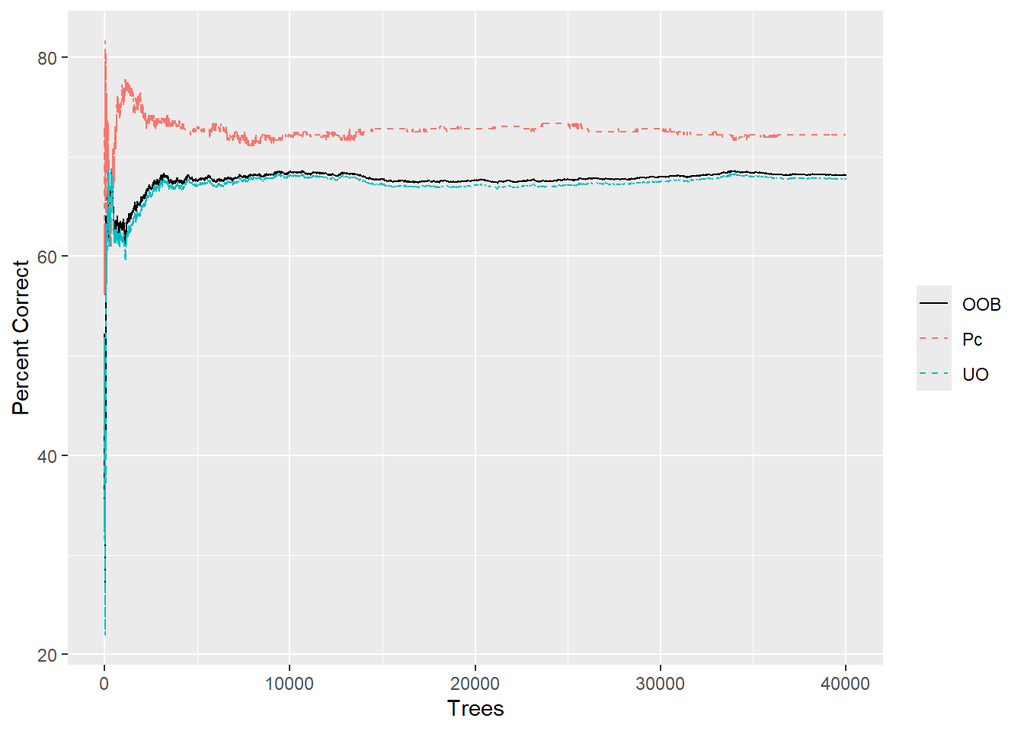

```
## Whistle_and_Moan_Detector
```

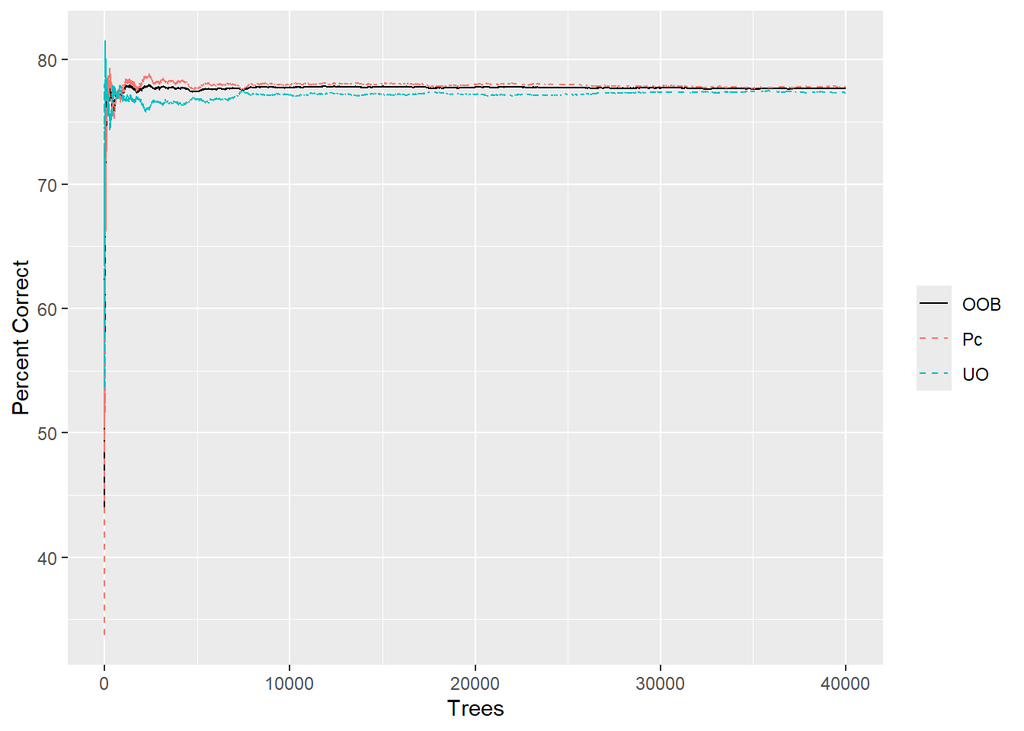

```r
detList <- names(bant.mdl@detectors)

for (d in seq_along(detList)){
  cat(detList[d], '\n')
  plotTrace(getBanterModel(bant.mdl, model = detList[d]))
  #plotInbag(getBanterModel(bant.mdl, model = d))
  # print(table(getBanterModel(bant.mdl, model = d)$oob.times))
}
```